# Türkiye Havalimanı Analizi

Zeynep KÜÇÜKÇAVDAR

7 Şubat 2017

# Türkiyedeki Havalimanları

Temel ulaşım sistemlerinden birini teşkil eden havayolu ulaşımı, diğer ulaşım sistemlerine göre sahip olduğu üstünlükler dolayısıyla her geçen gün daha fazla tercih edilmeye devam etmektedir. Bu gelişme sadece uluslararası taşımada değil aynı zamanda ülke içi ulaştırmada da belirgin bir hal almaya başlamış bulunmaktadır.

Geçekleştirilen yatırımlar sonucu, Türkiye’de havayolu ulaşımında özellikle son 20 yılda çok önemli ilerlemeler kaydedilmiş, bu süre zarfında düzenli ulaşım sağlanan havaalanı sayısı 16’dan 46’ya yükselmiştir. 1980’li yılların ortalarına kadar ulaşım tek şirket (THY) vasıtasıyla gerçekleştirilirken, 2010 yılında bu sayı 17’ye çıkmış, buna paralel olarak da uçak sayısı ve koltuk kapasitelerinde yüksek artışlar sağlanmıştır. Sektörde yaşanan bu olumlu gelişmeler, özellikle yolcu taşımasında büyük artışları da beraberinde getirmiş, 1990 yılında yaklaşık 13,5 milyon olan toplam yolcu sayısı 2010 yılı sonunda % 654 artışla ilk kez 100 milyonu aşmıştı

Türkiye Havalimanlarının işletilmesi ile Türkiye Hava sahasındaki hava trafiğinin düzenlenmesi ve kontrolü görevi, Devlet Hava Meydanları İşletmesi(DHMİ) Genel Müdürlüğünce yerine getirilmektedir.

## Havalimanı Olan İller

```r
Sys.setlocale(locale="Turkish")
```

```
## [1] "LC_COLLATE=Turkish_Turkey.1254;LC_CTYPE=Turkish_Turkey.1254;LC_MONETARY=Turkish_Turkey.1254;LC_NUMERIC=C;LC_TIME=Turkish_Turkey.1254"
```

```r
data=read.table("C:\\Users\\zeynep.kucukcavdar\\Desktop\\AB2017Data\\Proje\\Data.csv", header=T, sep=",", encoding="UTF-8")
datam=data[,1:19]
TumIllerSayi=count(datam %>% distinct (Airports))-1
mesaj=paste("Ülkede faaliyette olan",TumIllerSayi,"sivil havalimanından 23 ünde uluslararası uçuşlar gerçekleştirilmektedir.")
mesaj
```

```
## [1] "Ülkede faaliyette olan 55 sivil havalimanından 23 ünde uluslararası uçuşlar gerçekleştirilmektedir."
```

## Havalimanları Listesi

Aşağıda Türkiye’de 2015 yılı faaliyet gösteren tüm havalimanlarının adını bulabilirsiniz.

```r
Sys.setlocale(locale="Turkish")
```

```
## [1] "LC_COLLATE=Turkish_Turkey.1254;LC_CTYPE=Turkish_Turkey.1254;LC_MONETARY=Turkish_Turkey.1254;LC_NUMERIC=C;LC_TIME=Turkish_Turkey.1254"
```

```r
data=read.table("C:\\Users\\zeynep.kucukcavdar\\Desktop\\AB2017Data\\Proje\\Data.csv", header=T, sep=",", encoding="UTF-8")
datam=data[,1:19]

sehir="Turkiye"
TumIller=datam %>% distinct (Airports) %>% filter (Airports!=sehir)
TumIller
```

```
##                      Airports
## 1          Istanbul (Ataturk)
## 2    Istanbul (Sabiha Gokcen)
## 3            Tekirdag (Corlu)
## 4                   Balikesir
## 5     Balikesir  (Koca Seyit)
## 6                   Canakkale
## 7        Canakkale (Gokceada)
## 8      Izmir (Adnan Menderes)
## 9                Aydin Cildir
## 10           Denizli (Cardak)
## 11            Mugla (Dalaman)
## 12        Mugla (MilasBodrum)
## 13            Kutahya (Zafer)
## 14                       Usak
```

[output cut: 41 more lines]

Havalimanlarında iniş ve kalkış yapan uçakların sayıları ve bu uçaklar ile taşınan yolcu ve yük istatistikleri 2004 yılı itibari ile aşağıdaki listede özetlenmiştir.

```r
Sys.setlocale(locale="Turkish")
```

```
## [1] "LC_COLLATE=Turkish_Turkey.1254;LC_CTYPE=Turkish_Turkey.1254;LC_MONETARY=Turkish_Turkey.1254;LC_NUMERIC=C;LC_TIME=Turkish_Turkey.1254"
```

```r
data=read.table("C:\\Users\\zeynep.kucukcavdar\\Desktop\\AB2017Data\\Proje\\Data.csv", header=T, sep=",", encoding="UTF-8")
datam=data[,1:19]
TurkiyeOzet=datam  %>% filter(Airports==sehir) %>% dplyr::select(Year, AllAirCraft, Passengers.Total, TotalFreight)
TurkiyeOzet
```

```
##    Year AllAirCraft Passengers.Total TotalFreight
## 1  2004      440238         44789140      1126107
## 2  2005      534087         54525727      1249555
## 3  2006      594749         58778131      1279340
## 4  2007      642988         66463286      1447603
## 5  2008      688189         74968329      1534619
## 6  2009      715544         78742075      1597699
## 7  2010      919411        102800392      2021076
## 8  2011     1042369        117620469      2249474
## 9  2012     1093047        130351620      2249133
## 10 2013     1223795        149430421      2595316
## 11 2014     1345954        165720234      2893000
## 12 2015     1456673        181074531      3072831
```

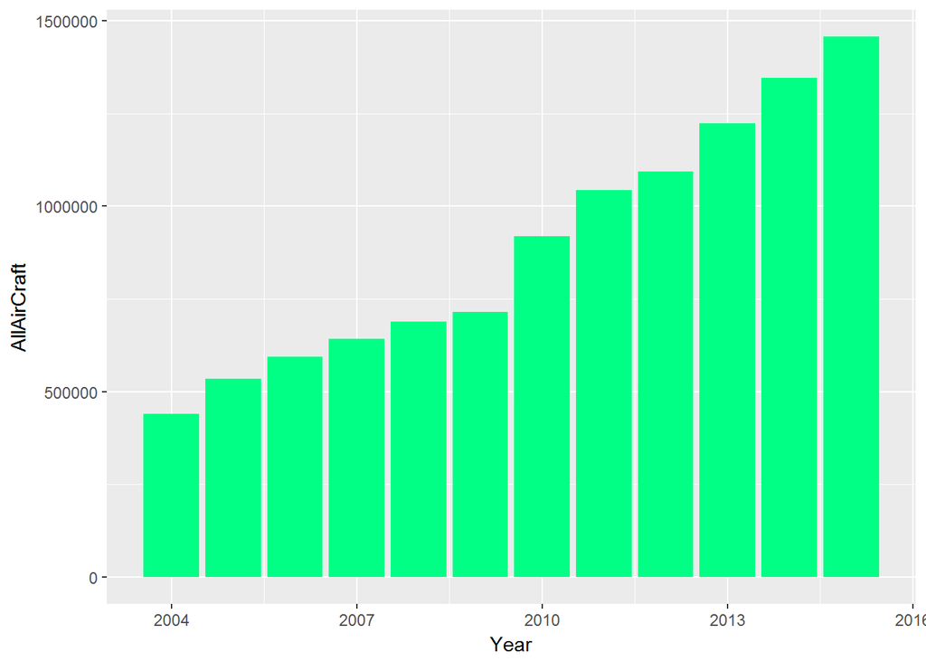

```r
TurkiyeOzetSadeceTRGGPlot=ggplot(data=TurkiyeOzet,aes(x=Year,y=AllAirCraft)) + geom_bar(stat="identity",fill="#00FF84")
TurkiyeOzetSadeceTRGGPlot
```

Türkiye genelindeki uçak, yolcu ve yük trafiği incelendiğinde ise, yolcu ve yük trafiğinin uçak sayısı büyümesine bağlı olarak arttığı söylenebilir. En hızlı büyümenin görüldüğü 2010 yılı, İstanbul ilinde Sabiha Gökçen Havalimanın açıldığı döneme denk gelmektedir.

```r
Sys.setlocale(locale="Turkish")
```

```
## [1] "LC_COLLATE=Turkish_Turkey.1254;LC_CTYPE=Turkish_Turkey.1254;LC_MONETARY=Turkish_Turkey.1254;LC_NUMERIC=C;LC_TIME=Turkish_Turkey.1254"
```

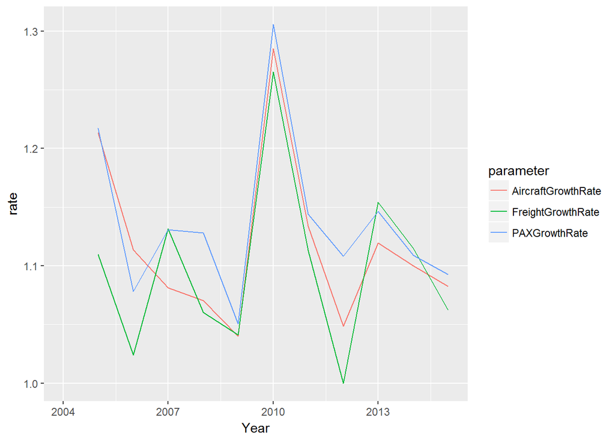

```r
data=read.table("C:\\Users\\zeynep.kucukcavdar\\Desktop\\AB2017Data\\Proje\\Data.csv", header=T, sep=",", encoding="UTF-8")
datam=data[,1:19]
sehir="Turkiye"
Growth2=datam %>% filter(Airports==sehir) %>% mutate (AircraftGrowthRate=AllAirCraft/lag(AllAirCraft,1),   #1 lag ile gotur
                                                        PAXGrowthRate=Passengers.Total/lag(Passengers.Total,1),
                                                        FreightGrowthRate=TotalFreight/lag(TotalFreight,1))
Growth3=Growth2 %>% dplyr::select (Year, AircraftGrowthRate,PAXGrowthRate,FreightGrowthRate ) %>% gather(key=parameter,value=rate,-Year)
ggplot(data=Growth3,aes(x=Year)) + geom_line(aes(y=rate,color=parameter))
```

Ayrıca 2015 yılı itibari ile inen-kalkan uçak sayısına göre en büyük ve en küçük havalimanları sırası ile aşağıdaki gibidir;

```r
Sys.setlocale(locale="Turkish")
```

```
## [1] "LC_COLLATE=Turkish_Turkey.1254;LC_CTYPE=Turkish_Turkey.1254;LC_MONETARY=Turkish_Turkey.1254;LC_NUMERIC=C;LC_TIME=Turkish_Turkey.1254"
```

```r
data=read.table("C:\\Users\\zeynep.kucukcavdar\\Desktop\\AB2017Data\\Proje\\Data.csv", header=T, sep=",", encoding="UTF-8")
datam=data[,1:19]

sehir="Turkiye"
sehirdatam=datam %>% filter(Airports!=sehir & Year==2015)
sehirmaxNOFdatam=sehirdatam %>% filter(AllAirCraft==max(AllAirCraft)) %>% dplyr::select (Airports, AllAirCraft, Passengers.Total, TotalFreight)
sehirminNOFdatam=sehirdatam %>% filter(AllAirCraft==min(AllAirCraft)) %>% dplyr::select (Airports, AllAirCraft,  Passengers.Total, TotalFreight)

MaxMinOzet=rbind(sehirmaxNOFdatam, sehirminNOFdatam)  #altlata ekledk
MaxMinOzet
```

```
##               Airports AllAirCraft Passengers.Total TotalFreight
## 1   Istanbul (Ataturk)      464774         61332124      1754724
## 2 Canakkale (Gokceada)         118                0            0
```

En büyük 10 havalimanı listesi ise;

```r
Sys.setlocale(locale="Turkish")
```

```
## [1] "LC_COLLATE=Turkish_Turkey.1254;LC_CTYPE=Turkish_Turkey.1254;LC_MONETARY=Turkish_Turkey.1254;LC_NUMERIC=C;LC_TIME=Turkish_Turkey.1254"
```

```r
data=read.table("C:\\Users\\zeynep.kucukcavdar\\Desktop\\AB2017Data\\Proje\\Data.csv", header=T, sep=",", encoding="UTF-8")
datam=data[,1:19]

sehir="Turkiye"
sehirdatam=datam %>% filter(Airports!=sehir & Year==2015)
sehirmax10nofdatam= arrange(sehirdatam, AllAirCraft) %>% dplyr::select (Airports) %>%slice ((length(sehirdatam[,1])-9):length(sehirdatam[,1]))
sehirmax10nofdatam
```

```
##                    Airports
## 1                   Trabzon
## 2          Tekirdag (Corlu)
## 3           Mugla (Dalaman)
## 4       Mugla (MilasBodrum)
## 5                     Adana
## 6    Izmir (Adnan Menderes)
## 7         Ankara (Esenboga)
## 8                   Antalya
## 9  Istanbul (Sabiha Gokcen)
## 10       Istanbul (Ataturk)
```

## Hava Trafiği Oranları

2015 yılı uçak trafiği oranları;

```r
Sys.setlocale(locale="Turkish")
```

```
## [1] "LC_COLLATE=Turkish_Turkey.1254;LC_CTYPE=Turkish_Turkey.1254;LC_MONETARY=Turkish_Turkey.1254;LC_NUMERIC=C;LC_TIME=Turkish_Turkey.1254"
```

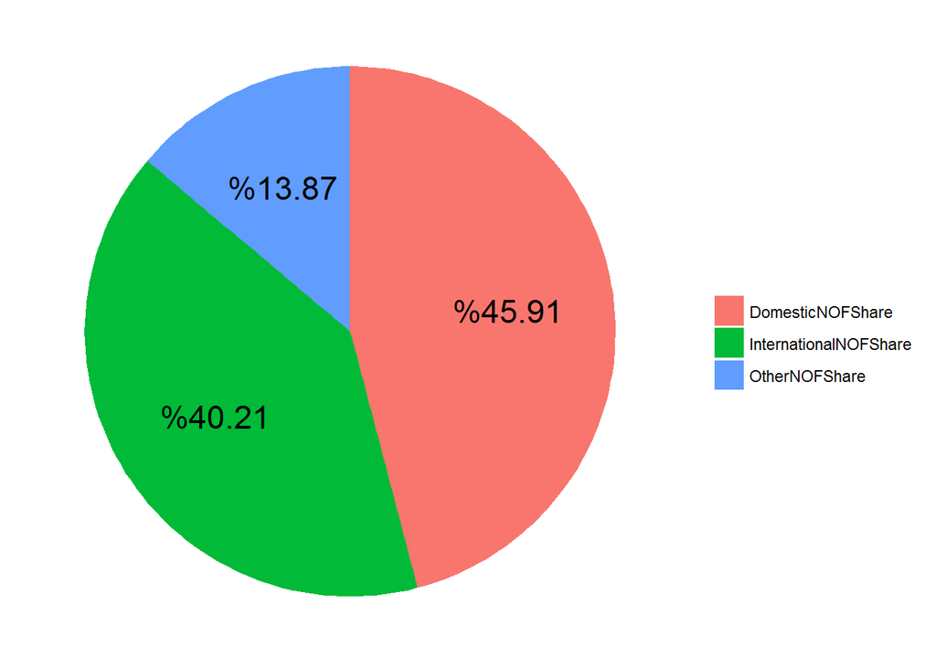

```r
data=read.table("C:\\Users\\zeynep.kucukcavdar\\Desktop\\AB2017Data\\Proje\\Data.csv", header=T, sep=",", encoding="UTF-8")
datam=data[,1:19]

sehir="Turkiye"
sehirdatam=datam %>% filter(Airports==sehir)
Share= sehirdatam %>% transmute (Year, DomesticNOFShare=round(100*(DomesticTurkish/AllAirCraft),2),
                                 Year, InternationalNOFShare=round(100*(InternationalTF/AllAirCraft),2),
                                 Year, OtherNOFShare=round(100*(OtherAirCrafts/AllAirCraft),2),
                                 Year, DomesticPAXShare=round(100*(DomesticPAX/Passengers.Total),2),
                                 Year, InternationalPAXShare=round(100*(InternationalPAX/Passengers.Total),2),
                                 Year, CargoShare=round(100*(TotalCargo/TotalFreight),2),
                                 Year, BaggageShare=round(100*(TotalBaggage/TotalFreight),2),
                                 Year, MailShare=round(100*(TotalMail/TotalFreight),2),
                                 Year, DomesticCargoShare=round(100*(DomesticCargo/(DomesticCargo+InternationalCargo)),2),
                                 Year, InternationalCargoShare=round(100*(InternationalCargo/(DomesticCargo+InternationalCargo)),2),
                                 Year, DomesticBaggageShare=round(100*(DomesticBaggage/(DomesticBaggage+InternationalBaggage)),2),
                                 Year, InternationalBaggageShare=round(100*(InternationalBaggage/(DomesticBaggage+InternationalBaggage)),2),
                                 Year, DomesticMailShare=round(100*(DomesticMail/(DomesticMail+InternationalMail)),2),
                                Year, InternationalMailShare=round(100*(InternationalMail/(DomesticMail+InternationalMail)),2))

NOFShare= Share %>% filter (Year ==2015) %>% dplyr::select (DomesticNOFShare, InternationalNOFShare, OtherNOFShare)
PAXShare= Share %>% filter (Year ==2015) %>% dplyr::select (DomesticPAXShare, InternationalPAXShare)
CargoShare= Share %>% filter (Year ==2015) %>% dplyr::select (DomesticCargoShare, InternationalCargoShare)
BaggageShare= Share %>% filter (Year ==2015) %>% dplyr::select (DomesticBaggageShare, InternationalBaggageShare)
MailShare= Share %>% filter (Year ==2015) %>% dplyr::select (DomesticMailShare, InternationalMailShare)
ShareOzet=cbind(NOFShare, PAXShare,CargoShare,BaggageShare, MailShare)

ShareOzetG = ShareOzet %>%  dplyr::select(DomesticNOFShare,InternationalNOFShare,OtherNOFShare) %>%
              gather(key=parameter,value=rate) %>%
              arrange(parameter) %>%
              mutate(
                #parameter=ordered(parameter,levels=c("NOFShare","PAXShare","CargoShare","BaggageShare","MailShare")),
              konum=(100-(cumsum(rate)-rate/2)))

ggplot(data=ShareOzetG,aes(x="",y=rate,fill=parameter)) +
  geom_bar(stat="identity",width=1) +
  coord_polar("y",direction=-1) +
  #Temayı boş tut
  theme_void() +
  #Oy oranlarını ekle
  geom_text(aes(label = paste0("%",round(rate,4)),y=konum,x=1.1),size=6,angle=0) +
  #Lejant başlığını kaldır
  labs(fill="")
```

2015 yılı yolcu trafiği oranları;

```r
Sys.setlocale(locale="Turkish")
```

```
## [1] "LC_COLLATE=Turkish_Turkey.1254;LC_CTYPE=Turkish_Turkey.1254;LC_MONETARY=Turkish_Turkey.1254;LC_NUMERIC=C;LC_TIME=Turkish_Turkey.1254"
```

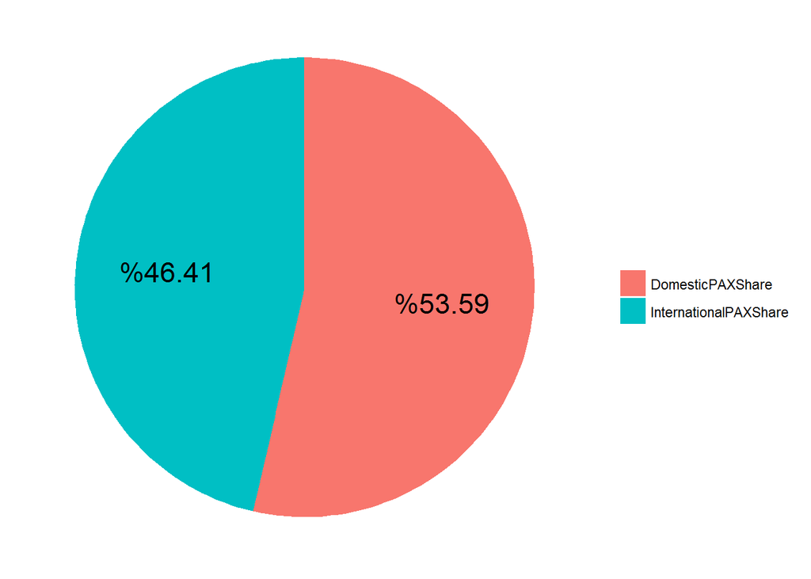

```r
data=read.table("C:\\Users\\zeynep.kucukcavdar\\Desktop\\AB2017Data\\Proje\\Data.csv", header=T, sep=",", encoding="UTF-8")
datam=data[,1:19]

sehir="Turkiye"
sehirdatam=datam %>% filter(Airports==sehir)
Share= sehirdatam %>% transmute (Year, DomesticNOFShare=round(100*(DomesticTurkish/AllAirCraft),2),
                                 Year, InternationalNOFShare=round(100*(InternationalTF/AllAirCraft),2),
                                 Year, OtherNOFShare=round(100*(OtherAirCrafts/AllAirCraft),2),
                                 Year, DomesticPAXShare=round(100*(DomesticPAX/Passengers.Total),2),
                                 Year, InternationalPAXShare=round(100*(InternationalPAX/Passengers.Total),2),
                                 Year, CargoShare=round(100*(TotalCargo/TotalFreight),2),
                                 Year, BaggageShare=round(100*(TotalBaggage/TotalFreight),2),
                                 Year, MailShare=round(100*(TotalMail/TotalFreight),2),
                                 Year, DomesticCargoShare=round(100*(DomesticCargo/(DomesticCargo+InternationalCargo)),2),
                                 Year, InternationalCargoShare=round(100*(InternationalCargo/(DomesticCargo+InternationalCargo)),2),
                                 Year, DomesticBaggageShare=round(100*(DomesticBaggage/(DomesticBaggage+InternationalBaggage)),2),
                                 Year, InternationalBaggageShare=round(100*(InternationalBaggage/(DomesticBaggage+InternationalBaggage)),2),
                                 Year, DomesticMailShare=round(100*(DomesticMail/(DomesticMail+InternationalMail)),2),
                                Year, InternationalMailShare=round(100*(InternationalMail/(DomesticMail+InternationalMail)),2))

NOFShare= Share %>% filter (Year ==2015) %>% dplyr::select (DomesticNOFShare, InternationalNOFShare, OtherNOFShare)
PAXShare= Share %>% filter (Year ==2015) %>% dplyr::select (DomesticPAXShare, InternationalPAXShare)
CargoShare= Share %>% filter (Year ==2015) %>% dplyr::select (DomesticCargoShare, InternationalCargoShare)
BaggageShare= Share %>% filter (Year ==2015) %>% dplyr::select (DomesticBaggageShare, InternationalBaggageShare)
MailShare= Share %>% filter (Year ==2015) %>% dplyr::select (DomesticMailShare, InternationalMailShare)
ShareOzet=cbind(NOFShare, PAXShare,CargoShare,BaggageShare, MailShare)

ShareOzetG = ShareOzet %>%  dplyr::select(DomesticPAXShare, InternationalPAXShare) %>%
  gather(key=parameter,value=rate) %>%
  arrange(parameter) %>%
  mutate(
    #parameter=ordered(parameter,levels=c("NOFShare","PAXShare","CargoShare","BaggageShare","MailShare")),
    konum=(100-(cumsum(rate)-rate/2)))

ggplot(data=ShareOzetG,aes(x="",y=rate,fill=parameter)) +
  geom_bar(stat="identity",width=1) +
  coord_polar("y",direction=-1) +
  #Temayı boş tut
  theme_void() +
  #Oy oranlarını ekle
  geom_text(aes(label = paste0("%",round(rate,4)),y=konum,x=1.1),size=6,angle=0) +
  #Lejant başlığını kaldır
  labs(fill="")
```

2015 yılı kargo trafiği oranları;

```r
Sys.setlocale(locale="Turkish")
```

```
## [1] "LC_COLLATE=Turkish_Turkey.1254;LC_CTYPE=Turkish_Turkey.1254;LC_MONETARY=Turkish_Turkey.1254;LC_NUMERIC=C;LC_TIME=Turkish_Turkey.1254"
```

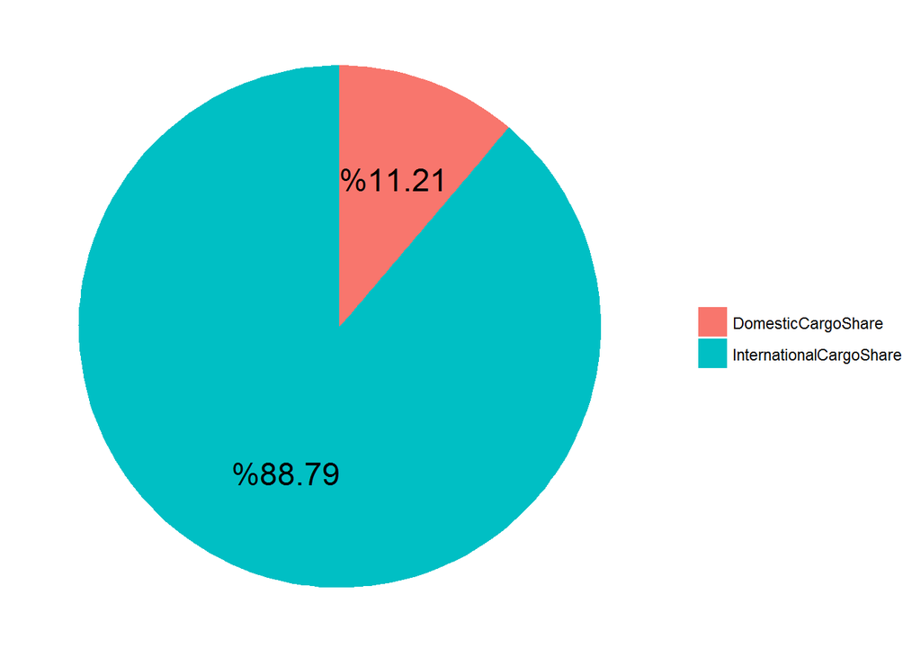

```r
data=read.table("C:\\Users\\zeynep.kucukcavdar\\Desktop\\AB2017Data\\Proje\\Data.csv", header=T, sep=",", encoding="UTF-8")
datam=data[,1:19]

sehir="Turkiye"
sehirdatam=datam %>% filter(Airports==sehir)
Share= sehirdatam %>% transmute (Year, DomesticNOFShare=round(100*(DomesticTurkish/AllAirCraft),2),
                                 Year, InternationalNOFShare=round(100*(InternationalTF/AllAirCraft),2),
                                 Year, OtherNOFShare=round(100*(OtherAirCrafts/AllAirCraft),2),
                                 Year, DomesticPAXShare=round(100*(DomesticPAX/Passengers.Total),2),
                                 Year, InternationalPAXShare=round(100*(InternationalPAX/Passengers.Total),2),
                                 Year, CargoShare=round(100*(TotalCargo/TotalFreight),2),
                                 Year, BaggageShare=round(100*(TotalBaggage/TotalFreight),2),
                                 Year, MailShare=round(100*(TotalMail/TotalFreight),2),
                                 Year, DomesticCargoShare=round(100*(DomesticCargo/(DomesticCargo+InternationalCargo)),2),
                                 Year, InternationalCargoShare=round(100*(InternationalCargo/(DomesticCargo+InternationalCargo)),2),
                                 Year, DomesticBaggageShare=round(100*(DomesticBaggage/(DomesticBaggage+InternationalBaggage)),2),
                                 Year, InternationalBaggageShare=round(100*(InternationalBaggage/(DomesticBaggage+InternationalBaggage)),2),
                                 Year, DomesticMailShare=round(100*(DomesticMail/(DomesticMail+InternationalMail)),2),
                                Year, InternationalMailShare=round(100*(InternationalMail/(DomesticMail+InternationalMail)),2))

NOFShare= Share %>% filter (Year ==2015) %>% dplyr::select (DomesticNOFShare, InternationalNOFShare, OtherNOFShare)
PAXShare= Share %>% filter (Year ==2015) %>% dplyr::select (DomesticPAXShare, InternationalPAXShare)
CargoShare= Share %>% filter (Year ==2015) %>% dplyr::select (DomesticCargoShare, InternationalCargoShare)
BaggageShare= Share %>% filter (Year ==2015) %>% dplyr::select (DomesticBaggageShare, InternationalBaggageShare)
MailShare= Share %>% filter (Year ==2015) %>% dplyr::select (DomesticMailShare, InternationalMailShare)
ShareOzet=cbind(NOFShare, PAXShare,CargoShare,BaggageShare, MailShare)

ShareOzetG = ShareOzet %>%  dplyr::select(DomesticCargoShare, InternationalCargoShare) %>%
  gather(key=parameter,value=rate) %>%
  arrange(parameter) %>%
  mutate(
    #parameter=ordered(parameter,levels=c("NOFShare","PAXShare","CargoShare","BaggageShare","MailShare")),
    konum=(100-(cumsum(rate)-rate/2)))

ggplot(data=ShareOzetG,aes(x="",y=rate,fill=parameter)) +
  geom_bar(stat="identity",width=1) +
  coord_polar("y",direction=-1) +
  #Temayı boş tut
  theme_void() +
  #Oy oranlarını ekle
  geom_text(aes(label = paste0("%",round(rate,4)),y=konum,x=1.1),size=6,angle=0) +
  #Lejant başlığını kaldır
  labs(fill="")
```

2015 yılı baggage trafiği oranları;

```r
Sys.setlocale(locale="Turkish")
```

```
## [1] "LC_COLLATE=Turkish_Turkey.1254;LC_CTYPE=Turkish_Turkey.1254;LC_MONETARY=Turkish_Turkey.1254;LC_NUMERIC=C;LC_TIME=Turkish_Turkey.1254"
```

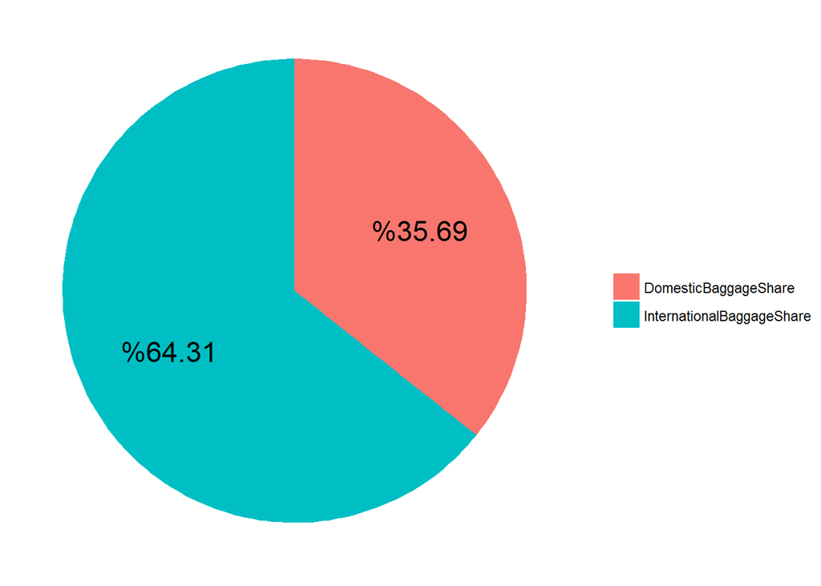

```r
data=read.table("C:\\Users\\zeynep.kucukcavdar\\Desktop\\AB2017Data\\Proje\\Data.csv", header=T, sep=",", encoding="UTF-8")
datam=data[,1:19]

sehir="Turkiye"
sehirdatam=datam %>% filter(Airports==sehir)
Share= sehirdatam %>% transmute (Year, DomesticNOFShare=round(100*(DomesticTurkish/AllAirCraft),2),
                                 Year, InternationalNOFShare=round(100*(InternationalTF/AllAirCraft),2),
                                 Year, OtherNOFShare=round(100*(OtherAirCrafts/AllAirCraft),2),
                                 Year, DomesticPAXShare=round(100*(DomesticPAX/Passengers.Total),2),
                                 Year, InternationalPAXShare=round(100*(InternationalPAX/Passengers.Total),2),
                                 Year, CargoShare=round(100*(TotalCargo/TotalFreight),2),
                                 Year, BaggageShare=round(100*(TotalBaggage/TotalFreight),2),
                                 Year, MailShare=round(100*(TotalMail/TotalFreight),2),
                                 Year, DomesticCargoShare=round(100*(DomesticCargo/(DomesticCargo+InternationalCargo)),2),
                                 Year, InternationalCargoShare=round(100*(InternationalCargo/(DomesticCargo+InternationalCargo)),2),
                                 Year, DomesticBaggageShare=round(100*(DomesticBaggage/(DomesticBaggage+InternationalBaggage)),2),
                                 Year, InternationalBaggageShare=round(100*(InternationalBaggage/(DomesticBaggage+InternationalBaggage)),2),
                                 Year, DomesticMailShare=round(100*(DomesticMail/(DomesticMail+InternationalMail)),2),
                                Year, InternationalMailShare=round(100*(InternationalMail/(DomesticMail+InternationalMail)),2))

NOFShare= Share %>% filter (Year ==2015) %>% dplyr::select (DomesticNOFShare, InternationalNOFShare, OtherNOFShare)
PAXShare= Share %>% filter (Year ==2015) %>% dplyr::select (DomesticPAXShare, InternationalPAXShare)
CargoShare= Share %>% filter (Year ==2015) %>% dplyr::select (DomesticCargoShare, InternationalCargoShare)
BaggageShare= Share %>% filter (Year ==2015) %>% dplyr::select (DomesticBaggageShare, InternationalBaggageShare)
MailShare= Share %>% filter (Year ==2015) %>% dplyr::select (DomesticMailShare, InternationalMailShare)
ShareOzet=cbind(NOFShare, PAXShare,CargoShare,BaggageShare, MailShare)

ShareOzetG = ShareOzet %>%  dplyr::select(DomesticBaggageShare, InternationalBaggageShare) %>%
  gather(key=parameter,value=rate) %>%
  arrange(parameter) %>%
  mutate(
    #parameter=ordered(parameter,levels=c("NOFShare","PAXShare","CargoShare","BaggageShare","MailShare")),
    konum=(100-(cumsum(rate)-rate/2)))


ggplot(data=ShareOzetG,aes(x="",y=rate,fill=parameter)) +
  geom_bar(stat="identity",width=1) +
  coord_polar("y",direction=-1) +
  #Temayı boş tut
  theme_void() +
  #Oy oranlarını ekle
  geom_text(aes(label = paste0("%",round(rate,4)),y=konum,x=1.1),size=6,angle=0) +
  #Lejant başlığını kaldır
  labs(fill="")
```

2015 yılı mail trafiği oranları;

```r
Sys.setlocale(locale="Turkish")
```

```
## [1] "LC_COLLATE=Turkish_Turkey.1254;LC_CTYPE=Turkish_Turkey.1254;LC_MONETARY=Turkish_Turkey.1254;LC_NUMERIC=C;LC_TIME=Turkish_Turkey.1254"
```

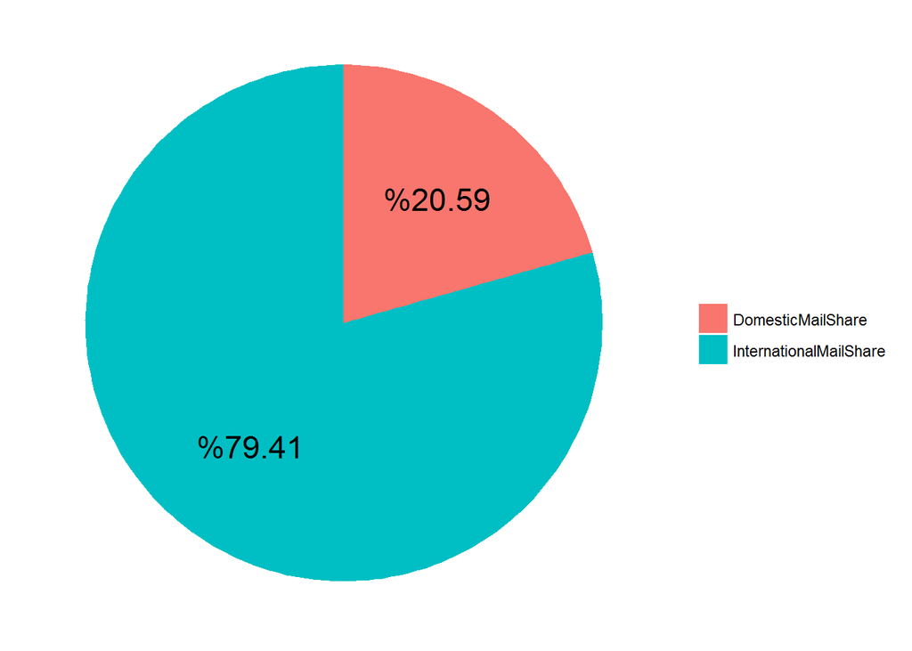

```r
data=read.table("C:\\Users\\zeynep.kucukcavdar\\Desktop\\AB2017Data\\Proje\\Data.csv", header=T, sep=",", encoding="UTF-8")
datam=data[,1:19]

sehir="Turkiye"
sehirdatam=datam %>% filter(Airports==sehir)
Share= sehirdatam %>% transmute (Year, DomesticNOFShare=round(100*(DomesticTurkish/AllAirCraft),2),
                                 Year, InternationalNOFShare=round(100*(InternationalTF/AllAirCraft),2),
                                 Year, OtherNOFShare=round(100*(OtherAirCrafts/AllAirCraft),2),
                                 Year, DomesticPAXShare=round(100*(DomesticPAX/Passengers.Total),2),
                                 Year, InternationalPAXShare=round(100*(InternationalPAX/Passengers.Total),2),
                                 Year, CargoShare=round(100*(TotalCargo/TotalFreight),2),
                                 Year, BaggageShare=round(100*(TotalBaggage/TotalFreight),2),
                                 Year, MailShare=round(100*(TotalMail/TotalFreight),2),
                                 Year, DomesticCargoShare=round(100*(DomesticCargo/(DomesticCargo+InternationalCargo)),2),
                                 Year, InternationalCargoShare=round(100*(InternationalCargo/(DomesticCargo+InternationalCargo)),2),
                                 Year, DomesticBaggageShare=round(100*(DomesticBaggage/(DomesticBaggage+InternationalBaggage)),2),
                                 Year, InternationalBaggageShare=round(100*(InternationalBaggage/(DomesticBaggage+InternationalBaggage)),2),
                                 Year, DomesticMailShare=round(100*(DomesticMail/(DomesticMail+InternationalMail)),2),
                                Year, InternationalMailShare=round(100*(InternationalMail/(DomesticMail+InternationalMail)),2))

NOFShare= Share %>% filter (Year ==2015) %>% dplyr::select (DomesticNOFShare, InternationalNOFShare, OtherNOFShare)
PAXShare= Share %>% filter (Year ==2015) %>% dplyr::select (DomesticPAXShare, InternationalPAXShare)
CargoShare= Share %>% filter (Year ==2015) %>% dplyr::select (DomesticCargoShare, InternationalCargoShare)
BaggageShare= Share %>% filter (Year ==2015) %>% dplyr::select (DomesticBaggageShare, InternationalBaggageShare)
MailShare= Share %>% filter (Year ==2015) %>% dplyr::select (DomesticMailShare, InternationalMailShare)
ShareOzet=cbind(NOFShare, PAXShare,CargoShare,BaggageShare, MailShare)

ShareOzetG = ShareOzet %>%  dplyr::select(DomesticMailShare, InternationalMailShare) %>%
  gather(key=parameter,value=rate) %>%
  arrange(parameter) %>%
  mutate(
    #parameter=ordered(parameter,levels=c("NOFShare","PAXShare","CargoShare","BaggageShare","MailShare")),
    konum=(100-(cumsum(rate)-rate/2)))

ggplot(data=ShareOzetG,aes(x="",y=rate,fill=parameter)) +
  geom_bar(stat="identity",width=1) +
  coord_polar("y",direction=-1) +
  #Temayı boş tut
  theme_void() +
  #Oy oranlarını ekle
  geom_text(aes(label = paste0("%",round(rate,4)),y=konum,x=1.1),size=6,angle=0) +
  #Lejant başlığını kaldır
  labs(fill="")
```